# Evaluating Winner’s Curse correction methods using real data sets

In this document, we will detail our investigation of the performance of various Winner’s Curse correction methods when they are applied to real data sets. These methods include 3 conditional likelihood approaches, Empirical Bayes, FDR Inverse Quantile Transformation and a bootstrap method which has been adapted for use with summary data. The methods were all implemented using the R package, `winnerscurse`. Note that we are focusing on those methods which make adjustments using only summary statistics from the discovery GWAS, rather than methods which combine information gained from both discovery and replication GWASs. In our study, the replication GWAS is used to assist in measuring how well each correction method performs.

We first begin with a discussion of the two data sets we have used, namely BMI and Type 2 Diabetes (T2D), and analyze the summary statistics obtained upon performing two independent GWASs for each trait. Recall that the Winner’s Curse is a statistical effect usually resulting in the exaggeration of SNP-trait association estimates in the sample in which these associations were discovered. In order to ensure that unbiased association estimates are obtained, the current common practice is that one GWAS is used to *discover* the significant SNPs and another GWAS, namely a replication GWAS, is performed to obtain the corresponding effect size estimates for each of these significant SNPs. For this reason, we randomly split the large data set in two for each trait, allowing us to conduct a *discovery* GWAS and a corresponding independent *replication* GWAS. The intention is that we will be able to compare the association estimates obtained in both GWASs for those SNPs that have been deemed significant in the *discovery* GWAS according to a specified threshold such as `5e-8`.

We then consider how these Winner’s Curse correction methods could be evaluated using this real data. Finally, we investigate various changes that could be made to these methods in order to potentially improve performance, allowing us to obtain more accurate association estimates.

**Note:** Our work begins at a starting point in which suitable quality control procedures have already been applied to the UKBB genotype data such as the removal of related individuals and the execution of principal component analysis. Further details of both R and shell scripts used can be found in `README.md`.

## BMI GWAS

The first data set which we will explore contains BMI information from a large number of individuals, obtained from the UKBB. The original data set contained BMI values for a total of 502,554 individuals. The pre-processing steps and implementation of `split_bmi.R` resulted in two independent data sets. The first, namely `bmi_gwasA.txt`, contained 166,286 individuals for which genotype data was also available while the second, namely `bmi_gwasB.txt` contained 166,332.

Using PLINK 2.0, we performed both GWASs and obtained two sets of summary statistics for a total of 7,915,560 SNPs. We will refer to the instance in which `bmi_gwasA.txt` has been used to conduct the discovery GWAS and `bmi_gwasB.txt` has been used for the replication GWAS as **BMI GWAS 1**. Similarly, we will refer to the case in which `bmi_gwasB.txt` has been used for the discovery GWAS and `bmi_gwasA.txt` for the replication as **BMI GWAS 2**.

In **BMI GWAS 1**, we find 6,908 significant SNPs at the `5e-8` threshold and 94,173 significant SNPs at the `5e-4` threshold. In **BMI GWAS 2**, there are 7,951 significant SNPs at the `5e-8` threshold and 98,351 significant SNPs at the `5e-4` threshold.

We proceed by plotting $z$ vs $\text{bias}$ for all SNPs, similar to plots produced in our simulation study. Here, we define $z = \frac{\beta_{\text{disc}}}{\text{se}_{\text{disc}}}$ and $\text{bias} = \beta_{\text{disc}} - \beta_{\text{rep}}$.

In **BMI GWAS 1**, we find that out of the 6,908 significant SNPs at `5e-8`, 4,929 of these SNPs have an association estimate which is more extreme in the discovery GWAS than in the replication, i.e. $\mid \beta_{\text{disc}} \mid > \mid \beta_{\text{rep}} \mid$. This is clear evidence of the bias induced by Winner’s Curse. Defining a SNP having a *significantly* more extreme effect size estimate in the discovery GWAS as one which satisfies $\mid \beta_{\text{disc}} \mid > \mid \beta_{\text{rep}} \mid + 1.96 \cdot \text{se}_{\text{disc}}$, we find that 1,555 SNPs have *significantly* more extreme association estimates in the discovery GWAS. These are SNPs which suffer from Winner’s Curse the most. In the below two plots, these SNPs which also pass a threshold of `5e-4` are highlighted in navy.

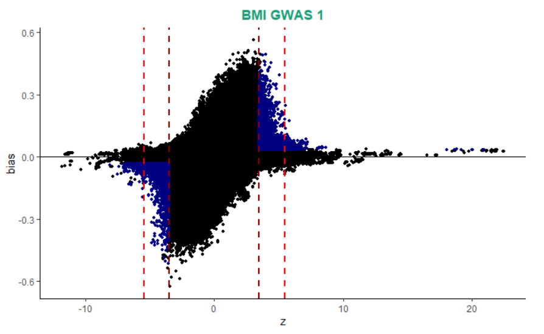

In **BMI GWAS 2**, we find that out of the 7,951 significant SNPs at `5e-8`, 6,368 of these SNPs have an association estimate which is more extreme in the discovery GWAS than in the replication. We find that 2,546 SNPs have *significantly* more extreme association estimates in the discovery GWAS.

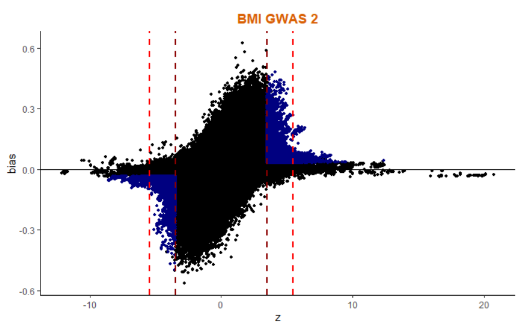

However, we notice in the above plot that many of the SNPs which have a $z$-value greater than 10 actually have negative bias, meaning that their association estimates in the replication GWAS are greater than their association estimate in the discovery GWAS. This is indeed contrary to what we would expect. *A possible explanation is that LD could be responsible for this observation?*.

We find there to be 3,562 SNPs which are in both sets of significant SNPs at the `5e-8` threshold, while there are 30,595 SNPs in both sets at the `5e-4` threshold.

We now construct two Manhattan-style plots, in which `position` is plotted against `abs(z)` for all SNPs, grouped by chromosome. Points in dark red represent SNPs which are also significant at the `5e-8` threshold in the corresponding replication GWAS.

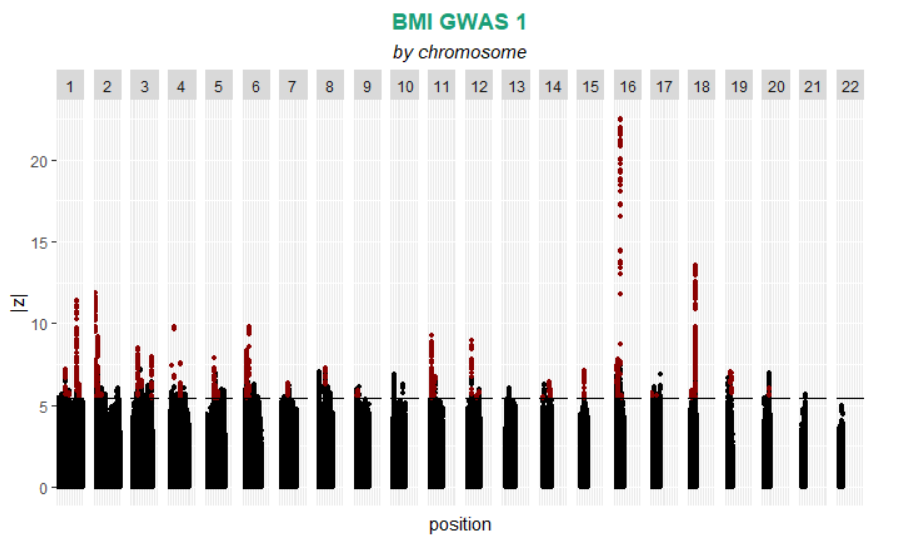

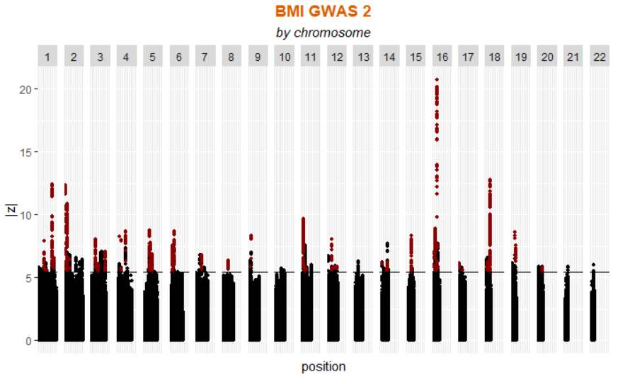

## T2D GWAS

The second data set which we will use contains T2D status for 502,524 individuals. The pre-processing steps and implementation of `split_T2D.R` resulted in two independent data sets. The first, namely `T2D_gwasA.txt`, contained 1,344 cases and 165,126 controls for which genotype data was also available while the second, namely `T2D_gwasB.txt` contained 1,297 cases and 165,875 controls.

Using PLINK 2.0, we performed both GWASs and obtained two sets of summary statistics for a total of 7,915,560 SNPs. Similar to what we have done above with BMI, we will refer to the instance in which `T2D_gwasA.txt` has been used to conduct the discovery GWAS and `T2D_gwasB.txt` has been used for the replication GWAS as **T2D GWAS 1**. Similarly, we will refer to the case in which `T2D_gwasB.txt` has been used for the discovery GWAS and `T2D_gwasA.txt` for the replication as **T2D GWAS 2**.

In **T2D GWAS 1**, we find 31 significant SNPs at the `5e-8` threshold and 5,832 significant SNPs at the `5e-4` threshold. In **T2D GWAS 2**, there are 76 significant SNPs at the `5e-8` threshold and 5507 significant SNPs at the `5e-4` threshold.

We plot $z$ vs $\text{bias}$ for all SNPs.

In **T2D GWAS 1**, we find that out of the 31 significant SNPs at `5e-8`, 2 of these SNPs have an association estimate which is more extreme in the discovery GWAS than in the replication. We find that both of these 2 SNPs have *significantly* more extreme association estimates in the discovery GWAS.

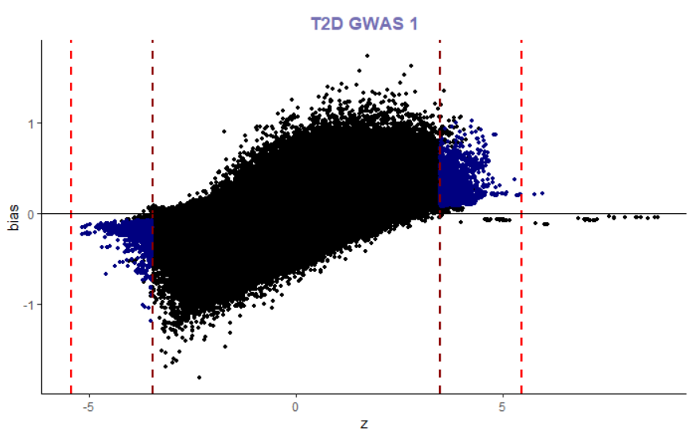

In **T2D GWAS 2**, we find that out of the 76 significant SNPs at `5e-8`, all 76 of these SNPs have an association estimate which is more extreme in the discovery GWAS than in the replication. We find that 12 SNPs have *significantly* more extreme association estimates in the discovery GWAS.

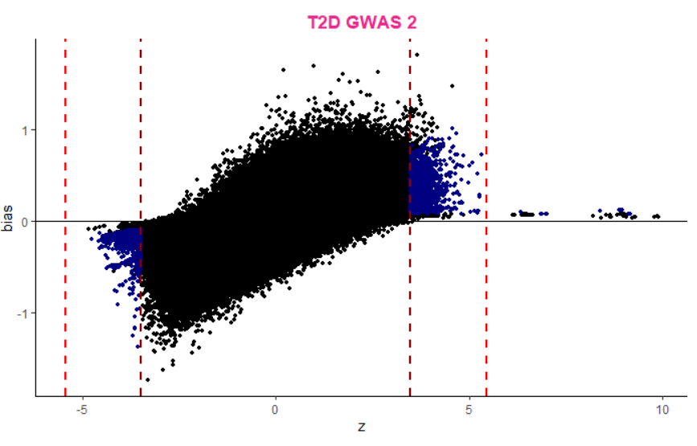

The plot of **T2D GWAS 1** is a certain cause for further investigation. We see that most significant SNPs have association estimates which are less in the discovery GWAS than in the replication GWAS. This observation is precisely the opposite of what we would anticipate. *We suspect that again LD may be having some effect here?*

We find there to be 29 SNPs which are in both sets of significant SNPs at the `5e-8` threshold, while there are 87 SNPs in both sets at the `5e-4` threshold.

Similar to above, we now construct two Manhattan-style plots, in which `position` is plotted against `abs(z)` for all SNPs, grouped by chromosome. Points in dark red represent SNPs which are also significant at the `5e-8` threshold in the corresponding replication GWAS.

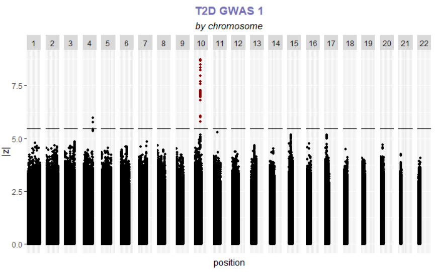

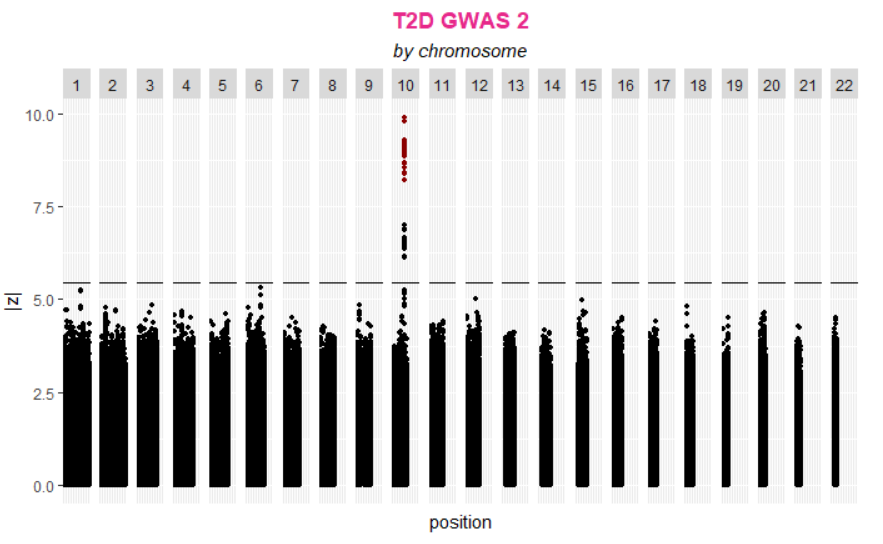

## Evaluating methods

As the main aim of our study is to evaluate Winner’s Curse correction methods, we apply these methods to the association estimates in all of our discovery GWASs to obtain adjusted association estimates and make comparisons based on the fact that *unbiased* association estimates have been obtained in the corresponding replication GWAS.

Thus, the key question which we intend to attempt to answer is as follows:

*Which method produces less biased estimates, i.e. estimates closest to those which would have been obtained in a replication study of similar size?*

Similar to what has been executed in relation to the simulation study, it is possible for evaluation to take place by considering mean squared error (mse). In the simulation study, we computed the following measurement over all $n$ significant SNPs:
$$\frac{1}{n} \sum^n_{i=1}
(\hat\beta_{\text{disc,adj},i} - \beta_i)^2,$$
however, due to the fact we are using real data sets, we don’t know the true effect size, $\beta_{i}$ for each significant SNP. Therefore, in this instance, we will apply the six different methods to the discovery GWAS and subsequently make use of the replication GWAS association estimates to assist us. We will evaluate the methods based on the following measurement over $n$ significant SNPs:
$$\frac{1}{n} \sum^n_{i=1}
(\hat\beta_{\text{disc,adj},i} - \hat\beta_{\text{rep},i})^2 -
\frac{1}{n} \sum^n_{i=1} (\text{se}_{\text{disc},i})^2,$$
or alternatively:
$$\sum^n_{i=1}
(\hat\beta_{\text{disc,adj},i} - \hat\beta_{\text{rep},i})^2 -
\sum^n_{i=1} (\text{se}_{\text{disc},i})^2.$$
We will refer to the first measurement as `mse` and to the second as `mse.n`.

### BMI 1

We begin by applying the methods and use a threshold of `5e-8` in order to classify significant SNPs. For **BMI GWAS 1**, we obtain the following adjusted association estimates for the top 6 significant SNPs and the SNPs in positions 1441-1446 based on significance.

```r
print(results[1:6,], row.names = FALSE)
```

```
##        rsid    beta      se beta.cl1 beta.cl2 beta.cl3 beta_EB beta_FIQT
##  rs11642015 0.37346 0.01659  0.37346  0.37346  0.37346 0.37137   0.36249
##  rs62048402 0.37339 0.01659  0.37339  0.37339  0.37339 0.37130   0.36248
##   rs1421085 0.37324 0.01659  0.37324  0.37324  0.37324 0.37115   0.36241
##   rs1558902 0.37332 0.01659  0.37332  0.37332  0.37332 0.37122   0.36249
##  rs55872725 0.37212 0.01659  0.37212  0.37212  0.37212 0.37003   0.36151
##  rs56094641 0.37199 0.01659  0.37199  0.37199  0.37199 0.36990   0.36144
##  beta_boot
##    0.36397
##    0.36393
##    0.36382
##    0.36389
##    0.36322
##    0.36312
```

```r
print(results[1441:1446,], row.names=FALSE)
```

```
##        rsid    beta      se beta.cl1 beta.cl2 beta.cl3 beta_EB beta_FIQT
##   rs4788078 0.12836 0.01685  0.12764  0.12549  0.12657 0.12836   0.10808
##  rs56272201 0.12808 0.01681  0.12736  0.12521  0.12629 0.12808   0.10784
##   rs4854269 0.12881 0.01691  0.12809  0.12593  0.12701 0.12881   0.10846
##    rs710410 0.12844 0.01686  0.12772  0.12556  0.12664 0.12844   0.10814
##    rs684227 0.12534 0.01646  0.12464  0.12253  0.12359 0.12534   0.10553
##  rs13107325 0.23706 0.03113  0.23573  0.23174  0.23373 0.23706   0.19959
##  beta_boot
##    0.11199
##    0.11174
##    0.11239
##    0.11206
##    0.10935
##    0.20680
```

In this set of results, we notice that the empirical Bayes method has failed to decrease the effect sizes of all SNPs. This is most likely due to the way in which the distribution of the data is being modelled but we will conduct a more detailed investigation into this later.

Bearing these observations in mind, we compute `mse` and `mse.n` and obtain the following:

```r
mse_BMI1
```

```
##          naive    beta.cl1     beta.cl2    beta.cl3      beta_EB    beta_FIQT
## 1 0.0006548724 0.001665055 0.0007066511 0.001081376 0.0003565754 0.0003870586
##      beta_boot
## 1 0.0003289772
```

```r
rmse_BMI1
```

```
##        naive   beta.cl1   beta.cl2   beta.cl3   beta_EB  beta_FIQT  beta_boot
## 1 0.02559047 0.04080509 0.02658291 0.03288429 0.0188832 0.01967381 0.01813773
```

```r
mse.n_BMI1
```

```
##      naive beta.cl1 beta.cl2 beta.cl3  beta_EB beta_FIQT beta_boot
## 1 4.523858  11.5022 4.881546 7.470148 2.463223  2.673801  2.272575
```

Here, it seems that it is in fact the bootstrap method which performs the best, obtaining the smallest values. However, the empirical Bayes approach and FDR IQT also have values which are less than that of the `naive` approach, i.e. using non-adjusted association estimates. This is an encouraging observation. That said, it is concerning that all of the three conditional likelihood methods demonstrate poor performance, when evaluated with this metric. We perhaps would have hoped to see lower values for the empirical Bayes method - this observation provides motivation to attempt improving the method, making it more suitable for application to real data.

We also have a look at computing these same quantities when the threshold is changed to a less stringent one of `5e-4`. Here, we obtain the following results:

```r
mse_BMI1_5e_4
```

```
##         naive    beta.cl1     beta.cl2    beta.cl3      beta_EB    beta_FIQT
## 1 0.002440761 0.001179601 0.0007799025 0.000872029 0.0007357532 0.0007672553
##     beta_BR_ss
## 1 0.0007652637
```

```r
rmse_BMI1_5e_4
```

```
##        naive   beta.cl1   beta.cl2   beta.cl3    beta_EB  beta_FIQT beta_BR_ss
## 1 0.04940405 0.03434533 0.02792673 0.02953014 0.02712477 0.02769937  0.0276634
```

```r
mse.n_BMI1_5e_4
```

```
##      naive beta.cl1 beta.cl2 beta.cl3  beta_EB beta_FIQT beta_boot
## 1 229.8537 111.0866 73.44576 82.12158 69.28808  72.25474  72.06718
```

We witness a similar pattern to that above but with all methods having lower values than that of the `naive` approach. It is the empirical Bayes method which performs the best in this instance.

### BMI 2

We repeat the above process for **BMI GWAS 2**. Here, we keep in mind what we observed in our $z$ vs $\text{bias}$ plot for **BMI GWAS 2** - we saw that for the most significant SNPs to the right of the plot, their association estimates in the replication GWAS were in fact *larger* than in the discovery GWAS. Thus, it is clear that considering the evaluation metrics that we are using, any method which reduces the association estimates of these SNPs would be seen to perform poorly compared to the `naive` approach for these particular SNPs.

```r
print(results[1:6,], row.names = FALSE)
```

```
##        rsid    beta      se beta.cl1 beta.cl2 beta.cl3 beta_EB beta_FIQT
##  rs11642015 0.34600 0.01668  0.34600  0.34600  0.34600 0.34076   0.33413
##  rs55872725 0.34590 0.01668  0.34590  0.34590  0.34590 0.34066   0.33407
##   rs1421085 0.34582 0.01668  0.34582  0.34582  0.34582 0.34058   0.33405
##   rs1558902 0.34579 0.01668  0.34579  0.34579  0.34579 0.34055   0.33413
##  rs62048402 0.34579 0.01668  0.34578  0.34579  0.34579 0.34054   0.33413
##  rs56094641 0.34530 0.01668  0.34530  0.34530  0.34530 0.34006   0.33379
##  beta_boot
##    0.33609
##    0.33601
##    0.33595
##    0.33595
##    0.33595
##    0.33557
```

```r
print(results[445:450,], row.names=FALSE)
```

```
##        rsid    beta      se beta.cl1 beta.cl2 beta.cl3 beta_EB beta_FIQT
##  rs35918659 0.21102 0.01899  0.21101  0.21101  0.21101 0.21102   0.19373
##  rs11662368 0.21088 0.01900  0.21088  0.21088  0.21088 0.21088   0.19357
##   rs8084085 0.21009 0.01894  0.21009  0.21009  0.21009 0.21009   0.19283
##  rs35578933 0.21001 0.01894  0.21001  0.21001  0.21001 0.21001   0.19275
##  rs17066562 0.20996 0.01894  0.20996  0.20996  0.20996 0.20996   0.19270
##   rs6567155 0.20994 0.01894  0.20994  0.20994  0.20994 0.20994   0.19267
##  beta_boot
##    0.20507
##    0.20489
##    0.20410
##    0.20401
##    0.20395
##    0.20391
```

We compute `mse` and `mse.n`:

```r
mse_BMI2
```

```
##        naive    beta.cl1     beta.cl2    beta.cl3      beta_EB    beta_FIQT
## 1 0.00148166 0.001624388 0.0006457771 0.001033301 0.0005797177 0.0005551994
##      beta_boot
## 1 0.0005649528
```

```r
rmse_BMI2
```

```
##        naive  beta.cl1   beta.cl2   beta.cl3    beta_EB  beta_FIQT  beta_boot
## 1 0.03849233 0.0403037 0.02541215 0.03214501 0.02407733 0.02356267 0.02376874
```

```r
mse.n_BMI2
```

```
##      naive beta.cl1 beta.cl2 beta.cl3  beta_EB beta_FIQT beta_boot
## 1 11.78067 12.91551 5.134574  8.21578 4.609336  4.414391   4.49194
```

Here, it is only the first conditional likelihood method that has values larger than the `naive` approach while FDR IQT is seen to perform the best overall.

We repeat using the larger threshold of `5e-4`:

```r
mse_BMI2_5e_4
```

```
##         naive   beta.cl1    beta.cl2    beta.cl3      beta_EB    beta_FIQT
## 1 0.002889462 0.00145181 0.001018003 0.001126171 0.0008535473 0.0008733975
##     beta_BR_ss
## 1 0.0008805454
```

```r
rmse_BMI2_5e_4
```

```
##        naive   beta.cl1   beta.cl2   beta.cl3    beta_EB beta_FIQT beta_BR_ss
## 1 0.05375371 0.03810262 0.03190616 0.03355847 0.02921553 0.0295533 0.02967399
```

```r
mse.n_BMI2_5e_4
```

```
##      naive beta.cl1 beta.cl2 beta.cl3  beta_EB beta_FIQT beta_boot
## 1 284.1814 142.7869 100.1216   110.76 83.94723  85.89952  86.60252
```

Again, we witness a similar pattern to above in which all methods perform better than the `naive` approach. It seems that at these less stringent thresholds, the empirical Bayes method continues to prove its ability in reducing the association estimates to values that are close to what would have been obtained in a replication GWAS of similar size.

### T2D 1

Now we turn to our first T2D GWAS. In the case of T2D, we see a much smaller number of SNPs passing the genome-wide significance threshold of `5e-8`. In a similar manner to **BMI GWAS 2**, we must be cautious here in our evaluation as we noticed that the majority of the significant SNPs here have *greater* association estimates in the replication GWAS than in the discovery GWAS. Therefore, we anticipate that none of these methods will perform as well as the `naive` approach when the threshold of `5e-8` is used.

We obtain the following adjusted association estimates for the top 6 significant SNPs.

```r
print(results[1:6,], row.names = FALSE)
```

```
##        rsid    beta      se beta.cl1 beta.cl2 beta.cl3 beta_EB beta_FIQT
##  rs35198068 0.34992 0.04007  0.34984  0.34892  0.34938 0.33920   0.26972
##   rs7903146 0.34750 0.04007  0.34741  0.34638  0.34690 0.33678   0.26974
##  rs34872471 0.34157 0.04020  0.34142  0.34003  0.34072 0.33082   0.26397
##  rs36090025 0.33337 0.03998  0.33312  0.33135  0.33223 0.32268   0.25614
##  rs10659211 0.33004 0.04009  0.32969  0.32759  0.32864 0.31931   0.25317
##   rs7074440 0.32863 0.03998  0.32828  0.32613  0.32721 0.31794   0.25249
##  beta_boot
##    0.32852
##    0.32364
##    0.31068
##    0.29667
##    0.28925
##    0.28748
```

We compute `mse` and `mse.n` and obtain the following:

```r
mse_T2D1
```

```
##         naive    beta.cl1   beta.cl2    beta.cl3    beta_EB  beta_FIQT
## 1 0.006411446 0.008107866 0.01004137 0.009032032 0.02353532 0.02389757
##    beta_boot
## 1 0.02016061
```

```r
rmse_T2D1
```

```
##        naive   beta.cl1  beta.cl2 beta.cl3   beta_EB beta_FIQT beta_boot
## 1 0.08007151 0.09004369 0.1002066 0.095037 0.1534122 0.1545884 0.1419881
```

```r
mse.n_T2D1
```

```
##       naive  beta.cl1  beta.cl2 beta.cl3   beta_EB beta_FIQT beta_boot
## 1 0.1987548 0.2513438 0.3112824 0.279993 0.7295949 0.7408248 0.6249788
```

As expected, the values for all methods are larger than that of the `naive` approach. Interestingly, it the is the first conditional likelihood method which has the lowest value of all methods. However, as these metrics are only being evaluated over 31 significant SNPs, most of which have *larger* association estimates in the replication GWAS, we will not place much emphasis on this set of results.

We now consider using a threshold of `5e-4`:

```r
mse_T2D1_5e_4
```

```
##        naive   beta.cl1   beta.cl2   beta.cl3     beta_EB   beta_FIQT
## 1 0.08836548 0.01576176 0.02868879 0.02046512 0.004775477 0.004463593
##   beta_BR_ss
## 1 0.01263988
```

```r
rmse_T2D1_5e_4
```

```
##       naive  beta.cl1  beta.cl2  beta.cl3    beta_EB  beta_FIQT beta_BR_ss
## 1 0.2972633 0.1255459 0.1693776 0.1430564 0.06910483 0.06681012  0.1124272
```

```r
mse.n_T2D1_5e_4
```

```
##      naive beta.cl1 beta.cl2 beta.cl3  beta_EB beta_FIQT beta_boot
## 1 515.3475 91.92261  167.313 119.3526 27.85058  26.03167  73.71578
```

These results can be understood to be much more appropriate than the previous set for comparing our Winner’s Curse correction methods. We see that all methods now have values less than that of the `naive` approach with the empirical Bayes approach and FDR IQT having the smallest values. Ideally, we would anticipate that empirical Bayes would perform better - perhaps making a modification to the method may allow it to make better adjustments to the estimated effect sizes of these significant SNPs? We will investigate this further later.

### T2D 2

For **T2D GWAS 2**, we obtain the following adjusted association estimates for the top 6 significant SNPs.

```r
print(results[1:6,], row.names = FALSE)
```

```
##        rsid    beta      se beta.cl1 beta.cl2 beta.cl3 beta_EB beta_FIQT
##  rs35198068 0.39978 0.04043  0.39977  0.39969  0.39973 0.35918   0.33183
##  rs34872471 0.40001 0.04053  0.40001  0.39992  0.39996 0.35931   0.33269
##   rs7903146 0.39605 0.04049  0.39605  0.39594  0.39599 0.35539   0.33008
##   rs7074440 0.37633 0.04049  0.37632  0.37600  0.37616 0.33567   0.30776
##  rs10659211 0.37476 0.04047  0.37475  0.37440  0.37457 0.33412   0.30712
##  rs36090025 0.37366 0.04048  0.37365  0.37328  0.37346 0.33300   0.30668
##  beta_boot
##    0.39528
##    0.39508
##    0.38925
##    0.35832
##    0.35597
##    0.35411
```

We compute `mse` and `mse.n`:

```r
mse_T2D2
```

```
##         naive    beta.cl1    beta.cl2    beta.cl3     beta_EB    beta_FIQT
## 1 0.003579806 0.002167959 0.001157571 0.001593969 0.003709755 -0.001279585
##       beta_boot
## 1 -0.0005688325
```

```r
rmse_T2D2
```

```
##        naive   beta.cl1   beta.cl2   beta.cl3    beta_EB beta_FIQT beta_boot
## 1 0.05983148 0.04656134 0.03402309 0.03992454 0.06090776       NaN       NaN
```

```r
mse.n_T2D2
```

```
##       naive  beta.cl1   beta.cl2  beta.cl3   beta_EB   beta_FIQT   beta_boot
## 1 0.2720652 0.1647649 0.08797536 0.1211416 0.2819414 -0.09724844 -0.04323127
```

We increase the threshold used to `5e-4`:

```r
mse_T2D2_5e_4
```

```
##       naive   beta.cl1   beta.cl2   beta.cl3    beta_EB   beta_FIQT beta_BR_ss
## 1 0.1036094 0.02051588 0.03668525 0.02673712 0.00851429 0.007812679 0.01827076
```

```r
rmse_T2D2_5e_4
```

```
##       naive  beta.cl1  beta.cl2  beta.cl3    beta_EB  beta_FIQT beta_BR_ss
## 1 0.3218842 0.1432336 0.1915339 0.1635149 0.09227291 0.08838936  0.1351694
```

```r
mse.n_T2D2_5e_4
```

```
##      naive beta.cl1 beta.cl2 beta.cl3 beta_EB beta_FIQT beta_boot
## 1 570.5772 112.9809 202.0257 147.2413 46.8882  43.02442   100.617
```

Here, we obtain very similar results to those of **T2D GWAS 1** at the same threshold and thus, they can be interpreted in the same manner.

## Improving methods

In this section, we investigate why some of the association estimates of significant SNPs are failing to be adjusted upon application of some of the Winner’s Curse correction methods. Our results above have motivated us to attempt to understand why certain methods are not performing that well in certain circumstances and to see if improvements can be made so that better adjusted association estimates can be obtained.

### Empirical Bayes

In relation to the empirical Bayes method, the function which executes this method contains a line of code which ensures that each association estimate gets reduced or if the method results in an increase in the estimate, then the association estimate will remain unadjusted. Thus, there must be certain regions in which this method is increasing the association estimates.

We first consider having a look at the empirical Bayes method in more detail with respect to **BMI GWAS 1**.

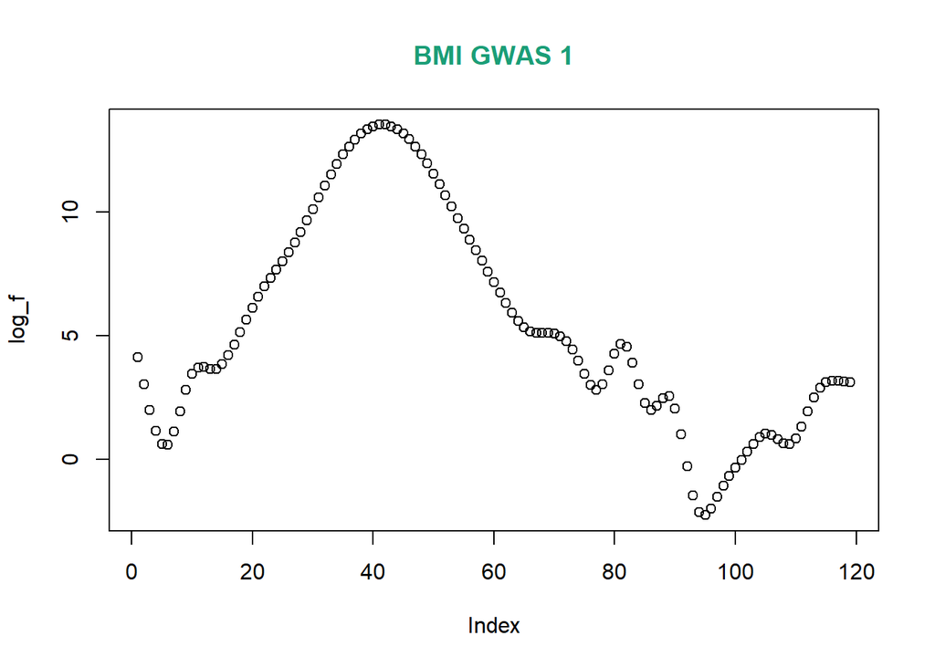

```r
z <- summary_data_bmi_1$beta/summary_data_bmi_1$se
bins <- seq(min(z),max(z),length.out=120)
mids <- (bins[-length(bins)]+bins[-1])/2
counts <- graphics::hist(z,breaks=bins,plot=F)$counts
most_extreme <- 10
boundary_lower <- sort(z)[most_extreme]
boundary_upper <- sort(z,decreasing=TRUE)[most_extreme]
df <- 7
AIC_vector <- c(rep(0,28))
for (best_df in 3:30){
  model <- stats::glm(counts ~ splines::ns(mids,knots = (seq(from=boundary_lower,to=boundary_upper,length=best_df+1)[2:best_df]), Boundary.knots=c(boundary_lower,boundary_upper)),stats::poisson,weights=rep(10^-50,length(counts)))
    minus2loglike <- 10^50*(model$deviance)
    AIC_vector[best_df-2] <- minus2loglike + 2*(best_df-2)
  }
df <- 2 + which.min(AIC_vector)

f <- stats::glm(counts ~ splines::ns(mids,knots = (seq(from=boundary_lower,to=boundary_upper,length=df+1)[2:df]), Boundary.knots=c(boundary_lower,boundary_upper)),stats::poisson,weight=rep(10^-50,length(counts)))$fit
f[f==0] <- min(f[f>0])
log_f <- as.vector(log(f))

## plot log_f
plot(log_f, main="BMI GWAS 1", col.main=col[1])
```

We expect this graph of `log_f` to be smooth. However, it demonstrates particularly unsmooth behaviour in the tails.

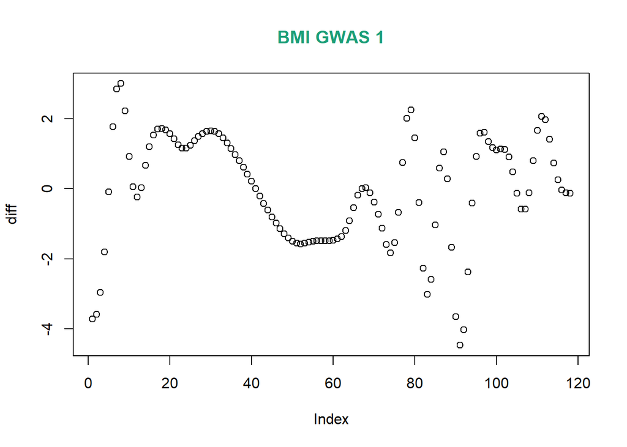

```r
diff <- diff(log_f)/diff(mids)

## plot diff
plot(diff, main="BMI GWAS 1", col.main=col[1])
```

In the above plot, we generally expect that `diff` would be positive to the left and then become negative. However, this doesn’t seem to be the case here at all. This serious issue is then translated into the adjustments made to the association estimates and is responsible for the method failing to adjust certain estimates.

We obtain `diff` plots for the other GWASs as follows:

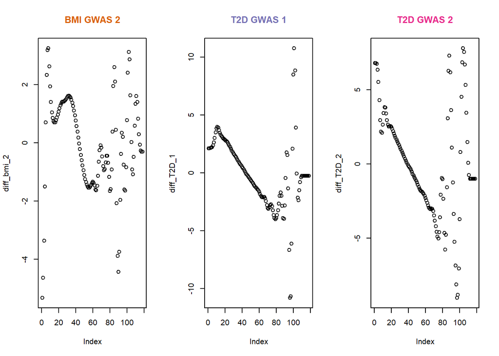

We see that these plots show similar ‘unsmoothness’ as the one obtained for **BMI GWAS 1**. Therefore, we must consider how we can counteract this issue. We look at three possible different ways to do this.

#### Shape Constrained Additive Model (SCAM)

We first examine restricting `f` to be a shape constrained additive model (SCAM). We can do so using the R package `scam` and constructing `f` as shown below.

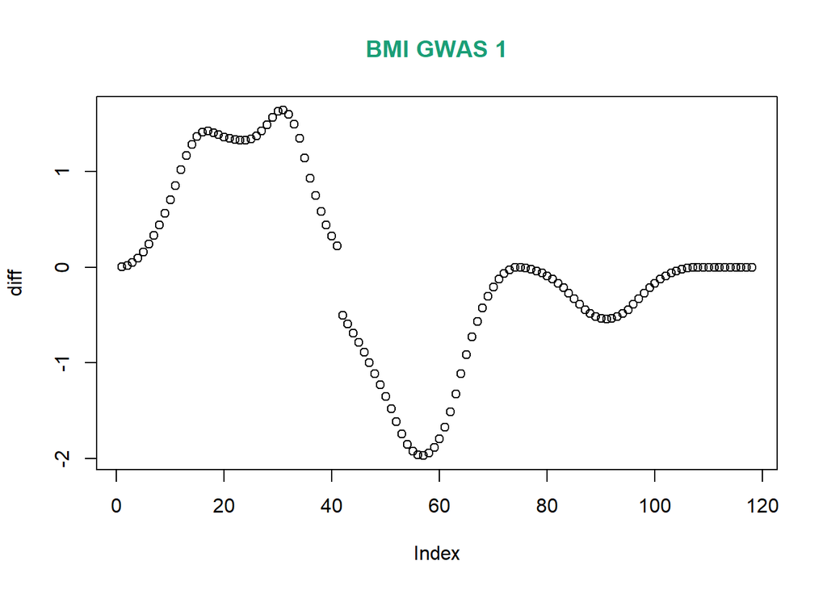

```r
z <- summary_data_bmi_1$beta/summary_data_bmi_1$se
bins <- seq(min(z),max(z),length.out=120)
mids <- (bins[-length(bins)]+bins[-1])/2
counts <- graphics::hist(z,breaks=bins,plot=F)$counts
data <- data.frame(counts,mids)
f1 <- scam(counts[mids >= 0] ~ s(mids[mids >= 0], bs="mpd"), family = poisson(link="log"), data = data)$fit
f2 <- scam(counts[mids < 0] ~ s(mids[mids < 0], bs="mpi"), family = poisson(link="log"), data = data)$fit
f <- c(f2,f1)
log_f <- as.vector(log(f))
diff <- diff(log_f)/diff(mids)
plot(diff, main="BMI GWAS 1", col.main=col[1])
```

This plot of `diff` is considerably smoother than the previous one above, even though there is evidence of discontinuity which is understandable as can be seen in the code above, we compute `f1` and then `f2`. The argument `bs="mpd"` is added in order to achieve monotone decreasing smooths. The coefficients are reparametrized so that they form a decreasing sequence. A first order difference penalty applied to the basis coefficients starting with the second is used for the monotone increasing and decreasing cases. Similarly, `bs="mpi"` is used to achieve monotone increasing smooths, in which the coefficients are reparametrized so that they form an increasing sequence.

We investigate what these `diff` plots look like for the other 3 GWASs when a shape constrained additive model has been used.

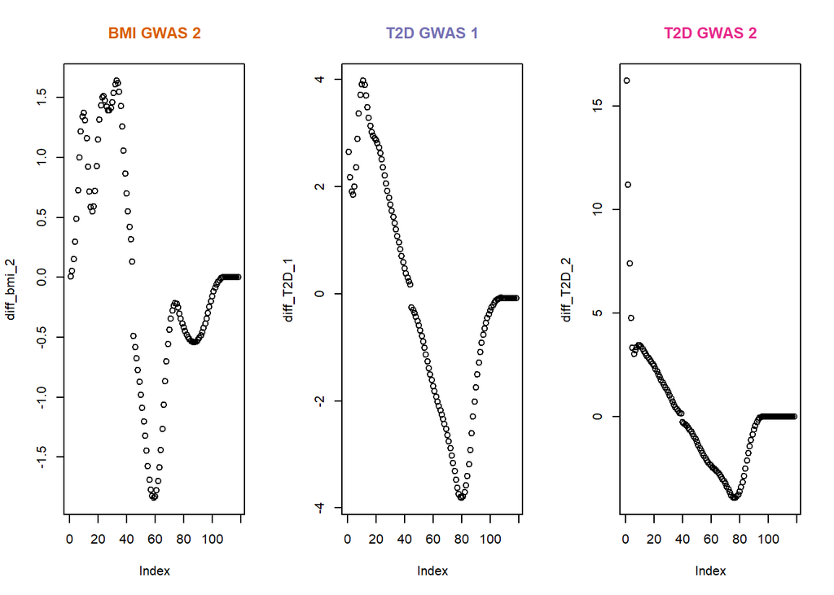

We note that these plots show similar improvements to the first one above with respect to smoothness. However, discontinuities in the middle are evident in all three plots.

We define a new function, namely `empirical_bayes_scam`, which implements the empirical Bayes method in which a shape constrained additive model is employed.

#### Generalized Additive Model (GAM)

The above modification to the empirical Bayes method can be seen to work well as it enforces additional constraints on the shape of the estimated log density function. Thus, similar functions which impose constraints on the shape may also perform well. Thus, we could also assess a variation of the empirical Bayes method in which the `gam` function in the R package `mgcv` is employed. The `gam` function fits a generalized additive model (GAM), with smoothness estimation integrated in the fitting process. The smoothing parameters are selected by means of generalized cross-validation (GCV). Two uses of this function were investigated, one in which the distribution family was specified as poisson and the other in which the identification of the family as negative binomial took place.

The function definition remains extremely similar to that above but with the following lines

`f1 <- scam(counts[mids >= 0] ~ s(mids[mids >= 0], bs="mpd"), family = poisson(link="log"), data = data)$fit` `f2 <- scam(counts[mids < 0] ~ s(mids[mids < 0], bs="mpi"), family = poisson(link="log"), data = data)$fit` `f <- c(f2,f1)`

replaced with

`f <- mgcv::gam(counts ~ s(mids), family=poisson(), data=data)$fit` or

`f <- mgcv::gam(counts ~ s(mids), family=mgcv::nb(), data=data)$fit`.

#### Fixing the degrees of freedom

The current version of the empirical Bayes method uses an AIC approach to choose an appropriate degrees of freedom. However, it is most likely that this AIC approach is not working optimally due to the large amount of LD present in our full datasets. Thus, we will proceed with an empirical analysis in which we vary the value for the degrees of freedom and compute the corresponding `mse` for each GWAS. The plots below illustrate the results that we obtained, in which we have included a third dataset, namely height. This third dataset is discussed in more detail below. The degrees of freedom is on the x-axis while `mse` is on the y-axis. The square point indicates the degrees of freedom which provided the lowest `mse` for that GWAS. The straight lines included indicate the `mse` obtained using the `naive` approach for each GWAS as a sort of ‘benchmark’ for comparison. Some points or lines may be missing as limits have been put on the y-axis, however these points or lines are ones which are greater than the max y-value on the plot.

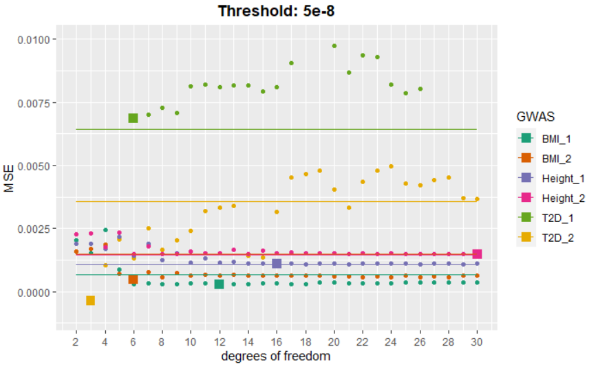

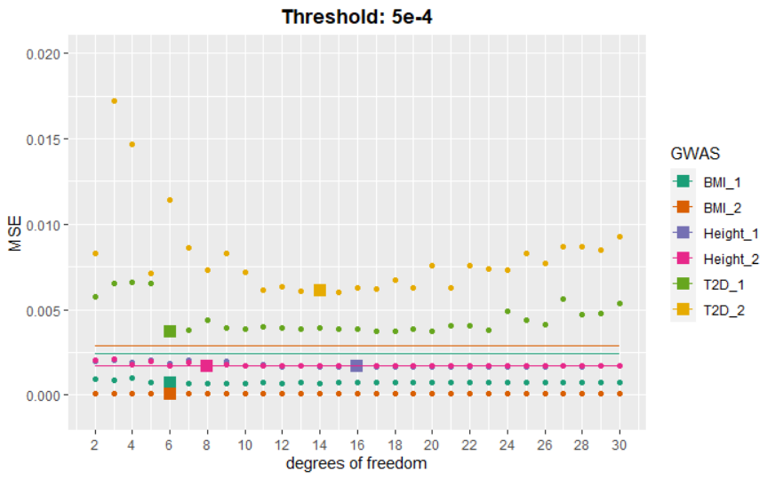

Thus, based on this empirical analysis of real data sets, it seems appropriate to suggest using a pre-specified value for the degrees of freedom. It was suggested by Efron [2009] that 7 degrees of freedom should be used and therefore, based on his paper and our above results, we decide to fix the degrees of freeedom at 7 instead of used the AIC approach. In `winnerscurse` package, using `èmpirical_bayes()` we can set `method="fix_df"`. This perhaps should be the most commonly employed approach when applying the empirical Bayes method to real data sets unless the researcher is certain that there is a minimal degree of LD in their array. Below, we will see what this adaptation means for us in terms of our chosen evaluation metrics.

### Re-evaluating methods

We have suggested several modifications that could be made to the empirical Bayes approach. In order to evaluate if these changes improve the method, we repeat what we have done above in terms of computing three defined metrics, `mse`, `rmse` and `mse.n`.

#### BMI GWAS 1

As before, we will first apply a threshold of `5e-8` in order to classify significant SNPs and subsequently, a threshold of `5e-4`.

```r
mse_BMI1
```

```
##          naive         CL1          CL2         CL3           EB        EB_df
## 1 0.0006548724 0.001665055 0.0007066511 0.001081376 0.0003565754 0.0003148336
##        EB_scam    EB_gam_po    EB_gam_nb         boot         FIQT
## 1 0.0003286228 0.0002941313 0.0003078188 0.0003289772 0.0003870586
```

```r
rmse_BMI1
```

```
##        naive        CL1        CL2        CL3        EB      EB_df    EB_scam
## 1 0.02559047 0.04080509 0.02658291 0.03288429 0.0188832 0.01774355 0.01812796
##    EB_gam_po  EB_gam_nb       boot       FIQT
## 1 0.01715026 0.01754477 0.01813773 0.01967381
```

```r
mse.n_BMI1
```

```
##      naive     CL1      CL2      CL3       EB    EB_df  EB_scam EB_gam_po
## 1 4.523858 11.5022 4.881546 7.470148 2.463223 2.174871 2.270126  2.031859
##   EB_gam_nb     boot     FIQT
## 1  2.126412 2.272575 2.673801
```

Using the greater threshold of `5e-4`, we obtain the following:

```r
mse_BMI1_5e_4
```

```
##         naive         CL1          CL2         CL3           EB        EB_df
## 1 0.002440761 0.001179601 0.0007799025 0.000872029 0.0007357532 0.0006880529
##        EB_scam    EB_gam_po    EB_gam_nb         boot         FIQT
## 1 0.0007101274 0.0007143643 0.0007137101 0.0007652637 0.0007672553
```

```r
rmse_BMI1_5e_4
```

```
##        naive        CL1        CL2        CL3         EB      EB_df    EB_scam
## 1 0.04940405 0.03434533 0.02792673 0.02953014 0.02712477 0.02623076 0.02664822
##    EB_gam_po  EB_gam_nb      boot       FIQT
## 1 0.02672759 0.02671535 0.0276634 0.02769937
```

```r
mse.n_BMI1_5e_4
```

```
##      naive      CL1      CL2      CL3       EB    EB_df  EB_scam EB_gam_po
## 1 229.8537 111.0866 73.44576 82.12158 69.28808 64.79601 66.87483  67.27383
##   EB_gam_nb     boot     FIQT
## 1  67.21223 72.06718 72.25474
```

These results are very similar to those above.

#### BMI GWAS 2

```r
mse_BMI2
```

```
##        naive         CL1          CL2         CL3           EB        EB_df
## 1 0.00148166 0.001624388 0.0006457771 0.001033301 0.0005797177 0.0007660964
##        EB_scam    EB_gam_po   EB_gam_nb         boot         FIQT
## 1 0.0005773651 0.0006091031 0.000588299 0.0005649528 0.0005551994
```

```r
rmse_BMI2
```

```
##        naive       CL1        CL2        CL3         EB      EB_df    EB_scam
## 1 0.03849233 0.0403037 0.02541215 0.03214501 0.02407733 0.02767845 0.02402842
##    EB_gam_po  EB_gam_nb       boot       FIQT
## 1 0.02468001 0.02425488 0.02376874 0.02356267
```

```r
mse.n_BMI2
```

```
##      naive      CL1      CL2     CL3       EB    EB_df EB_scam EB_gam_po
## 1 11.78067 12.91551 5.134574 8.21578 4.609336 6.091233 4.59063  4.842979
##   EB_gam_nb    boot     FIQT
## 1  4.677565 4.49194 4.414391
```

There is a slight contrast to our results for **BMI GWAS 1** here. Both adaptations have not significantly improved the empirical Bayes method, with the fixing of the degrees of freedom actually increasing the `mse` value.

```r
mse_BMI2_5e_4
```

```
##         naive        CL1         CL2         CL3           EB        EB_df
## 1 0.002889462 0.00145181 0.001018003 0.001126171 0.0008535473 0.0007868989
##        EB_scam    EB_gam_po    EB_gam_nb         boot         FIQT
## 1 0.0007666839 0.0008275886 0.0008077168 0.0008805454 0.0008733975
```

```r
rmse_BMI2_5e_4
```

```
##        naive        CL1        CL2        CL3         EB      EB_df    EB_scam
## 1 0.05375371 0.03810262 0.03190616 0.03355847 0.02921553 0.02805172 0.02768906
##    EB_gam_po  EB_gam_nb       boot      FIQT
## 1 0.02876784 0.02842036 0.02967399 0.0295533
```

```r
mse.n_BMI2_5e_4
```

```
##      naive      CL1      CL2    CL3       EB   EB_df  EB_scam EB_gam_po
## 1 284.1814 142.7869 100.1216 110.76 83.94723 77.3923 75.40412  81.39416
##   EB_gam_nb     boot     FIQT
## 1  79.43976 86.60252 85.89952
```

At this threshold, we do see that both modifications that we have made to the empirical Bayes method have resulted in improving the performance with respect to `mse`.

#### T2D GWAS 1

```r
mse_T2D1
```

```
##         naive         CL1        CL2         CL3         EB       EB_df
## 1 0.006411446 0.008107866 0.01004137 0.009032032 0.02353532 0.007009089
##       EB_scam   EB_gam_po   EB_gam_nb       boot       FIQT
## 1 0.007192436 0.007061293 0.007027865 0.02016061 0.02389757
```

```r
rmse_T2D1
```

```
##        naive        CL1       CL2      CL3        EB     EB_df    EB_scam
## 1 0.08007151 0.09004369 0.1002066 0.095037 0.1534122 0.0837203 0.08480823
##   EB_gam_po  EB_gam_nb      boot      FIQT
## 1 0.0840315 0.08383236 0.1419881 0.1545884
```

```r
mse.n_T2D1
```

```
##       naive       CL1       CL2      CL3        EB     EB_df   EB_scam
## 1 0.1987548 0.2513438 0.3112824 0.279993 0.7295949 0.2172817 0.2229655
##   EB_gam_po EB_gam_nb      boot      FIQT
## 1 0.2189001 0.2178638 0.6249788 0.7408248
```

Recall that this GWAS is one in which we witness that most of the significant SNPs at the `5e-8` threshold have estimated effect sizes that are in *greater* in the replication GWAS than in the discovery. For this reason, we still see that the `naive` approach has the smallest value here. That said, we see that the two modifications we have made to the empirical Bayes methods have `mse` values much closer to that of the `naive` approach.

```r
mse_T2D1_5e_4
```

```
##        naive        CL1        CL2        CL3          EB       EB_df
## 1 0.08836548 0.01576176 0.02868879 0.02046512 0.004775477 0.003798693
##       EB_scam   EB_gam_po   EB_gam_nb       boot        FIQT
## 1 0.003274817 0.003806319 0.003711768 0.01263988 0.004463593
```

```r
rmse_T2D1_5e_4
```

```
##       naive       CL1       CL2       CL3         EB      EB_df    EB_scam
## 1 0.2972633 0.1255459 0.1693776 0.1430564 0.06910483 0.06163354 0.05722602
##    EB_gam_po  EB_gam_nb      boot       FIQT
## 1 0.06169537 0.06092428 0.1124272 0.06681012
```

```r
mse.n_T2D1_5e_4
```

```
##      naive      CL1     CL2      CL3       EB    EB_df  EB_scam EB_gam_po
## 1 515.3475 91.92261 167.313 119.3526 27.85058 22.15398 19.09873  22.19845
##   EB_gam_nb     boot     FIQT
## 1  21.64703 73.71578 26.03167
```

#### T2D GWAS 2

```r
mse_T2D2
```

```
##         naive         CL1         CL2         CL3          EB       EB_df
## 1 0.003579806 0.002167959 0.001157571 0.001593969 0.003709755 0.002512997
##       EB_scam   EB_gam_po   EB_gam_nb          boot         FIQT
## 1 0.002520587 0.001941284 0.003296349 -0.0005688325 -0.001279585
```

```r
rmse_T2D2
```

```
##        naive        CL1        CL2        CL3         EB      EB_df    EB_scam
## 1 0.05983148 0.04656134 0.03402309 0.03992454 0.06090776 0.05012981 0.05020545
##    EB_gam_po  EB_gam_nb boot FIQT
## 1 0.04406001 0.05741384  NaN  NaN
```

```r
mse.n_T2D2
```

```
##       naive       CL1        CL2       CL3        EB     EB_df   EB_scam
## 1 0.2720652 0.1647649 0.08797536 0.1211416 0.2819414 0.1909878 0.1915646
##   EB_gam_po EB_gam_nb        boot        FIQT
## 1 0.1475376 0.2505225 -0.04323127 -0.09724844
```

The results here are not as straightforward as above. We still see that improvements have been made to the `mse` value of the original empirical Bayes method with the values of `beta_EB_scam` and `beta_EB_df` now below that of the `naive` approach.

```r
mse_T2D2_5e_4
```

```
##       naive        CL1        CL2        CL3         EB       EB_df     EB_scam
## 1 0.1036094 0.02051588 0.03668525 0.02673712 0.00851429 0.008619009 0.008333916
##     EB_gam_po   EB_gam_nb       boot        FIQT
## 1 0.007319911 0.006259174 0.01827076 0.007812679
```

```r
rmse_T2D2_5e_4
```

```
##       naive       CL1       CL2       CL3         EB      EB_df    EB_scam
## 1 0.3218842 0.1432336 0.1915339 0.1635149 0.09227291 0.09283862 0.09129029
##    EB_gam_po  EB_gam_nb      boot       FIQT
## 1 0.08555648 0.07911494 0.1351694 0.08838936
```

```r
mse.n_T2D2_5e_4
```

```
##      naive      CL1      CL2      CL3      EB    EB_df  EB_scam EB_gam_po
## 1 570.5772 112.9809 202.0257 147.2413 46.8882 47.46488 45.89488  40.31075
##   EB_gam_nb    boot     FIQT
## 1  34.46927 100.617 43.02442
```

## Height GWAS

In addition to our detailed exploration of method performance above, we decided to investigate a third real data set, namely height. We followed the exact same procedure as the one used with the BMI data set illustrated previously.

The original data set contained height values for a total of 502,554 individuals. The pre-processing steps and implementation of `split_height.R` resulted in two independent data sets. The first, namely `height_gwasA.txt`, contained 166,250 individuals for which genotype data was also available while the second, namely `height_gwasB.txt` contained 166,687.

Using PLINK 2.0, we performed both GWASs and obtained two sets of summary statistics for a total of 7,915,560 SNPs. We will refer to the instance in which `height_gwasA.txt` has been used to conduct the discovery GWAS and `height_gwasB.txt` has been used for the replication GWAS as **Height GWAS 1**. Similarly, we will refer to the case in which `height_gwasB.txt` has been used for the discovery GWAS and `height_gwasA.txt` for the replication as **Height GWAS 2**.

In **Height GWAS 1**, we find that out of the 70,020 significant SNPs at `5e-8`, 45,119 of these SNPs have an association estimate which is more extreme in the discovery GWAS than in the replication. We find that 12,809 SNPs have *significantly* more extreme association estimates in the discovery GWAS. There are 257,000 SNPs which are significant at the larger`5e-4` threshold.

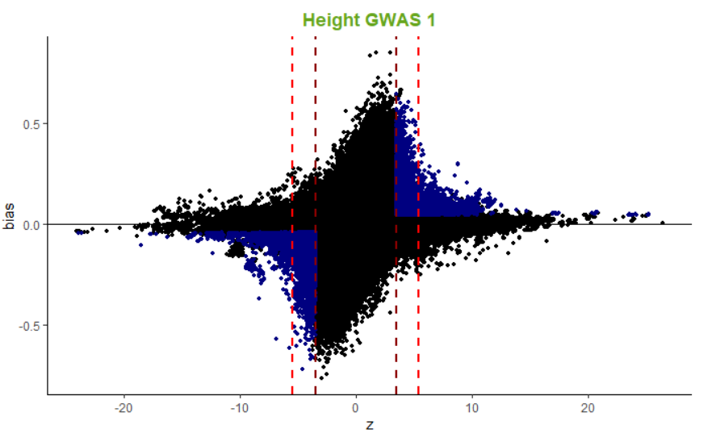

In **Height GWAS 2**, we find that out of the 70,634 significant SNPs at `5e-8`, 48,205 of these SNPs have an association estimate which is more extreme in the discovery GWAS than in the replication. We find that 12,514 SNPs have *significantly* more extreme association estimates in the discovery GWAS. There are 268,497 SNPs which are significant at the larger`5e-4` threshold.

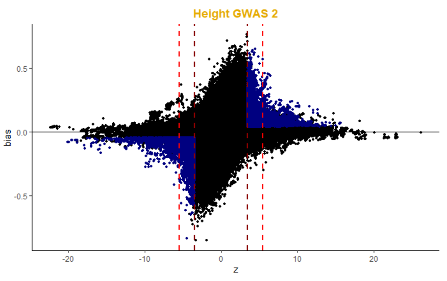

Similar to the other two traits, we notice in one GWAS that many SNPs with large $z$-values, in this case greater than 15, are seen to have association estimates in the replication GWAS which are greater than their corresponding association estimates in the discovery GWAS. Again, we hypothesize that LD is responsible for this as it is most likely that these SNPs all represent one independent signal, i.e. they are not independent from one another.

We find there to be 47,324 SNPs which are in both sets of significant SNPs at the `5e-8` threshold, while there are 154,389 SNPs in both sets at the `5e-4` threshold.

We now construct two Manhattan-style plots, in which `position` is plotted against `abs(z)` for all SNPs, grouped by chromosome. Points in dark red represent SNPs which are also significant at the `5e-8` threshold in the corresponding replication GWAS.

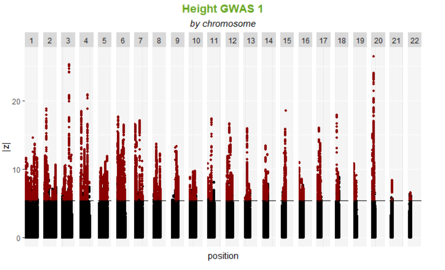

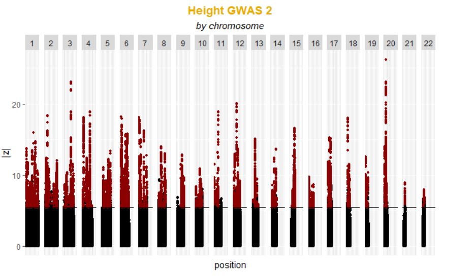

### Evaluating methods

#### Height 1

We begin by applying the methods, including the alternative forms of empirical Bayes discussed above, and use a threshold of `5e-8` in order to classify significant SNPs. For **Height GWAS 1**, we obtain the following adjusted association estimates for the top 6 significant SNPs.

```r
print(results[1:6,], row.names = FALSE)
```

```
##        rsid    beta      se beta.cl1 beta.cl2 beta.cl3 beta_EB beta_EB_scam
##    rs143384 0.58536 0.02210  0.58535  0.58536  0.58536 0.56415      0.58533
##    rs724016 0.55121 0.02182  0.55121  0.55121  0.55121 0.53053      0.55070
##   rs2871960 0.55090 0.02182  0.55090  0.55090  0.55090 0.53025      0.55037
##   rs1582874 0.55056 0.02181  0.55056  0.55056  0.55056 0.52992      0.55003
##  rs13068733 0.54981 0.02182  0.54981  0.54981  0.54981 0.52923      0.54923
##   rs7632381 0.54908 0.02180  0.54908  0.54908  0.54908 0.52854      0.54849
##  beta_EB_df beta_FIQT beta_boot
##     0.49659   0.57197   0.58536
##     0.46364   0.53806   0.54919
##     0.46331   0.53821   0.54883
##     0.46302   0.53791   0.54849
##     0.46225   0.53733   0.54763
##     0.46158   0.53690   0.54686
```

We now compute `mse` and `mse.n` and obtain the following:

```r
mse_height1
```

```
##         naive         CL1         CL2         CL3          EB       EB_df
## 1 0.001418471 0.004574445 0.002850487 0.003547625 0.001087342 0.001892434
##       EB_scam   EB_gam_po   EB_gam_nb        boot        FIQT
## 1 0.001158008 0.001400015 0.001181165 0.001116771 0.001147439
```

```r
rmse_height1
```

```
##       naive        CL1        CL2        CL3         EB      EB_df    EB_scam
## 1 0.0376626 0.06763464 0.05338995 0.05956195 0.03297487 0.04350212 0.03402952
##    EB_gam_po  EB_gam_nb       boot       FIQT
## 1 0.03741677 0.03436808 0.03341813 0.03387387
```

```r
mse.n_height1
```

```
##      naive      CL1      CL2      CL3       EB    EB_df  EB_scam EB_gam_po
## 1 99.32136 320.3026 199.5911 248.4047 76.13571 132.5082 81.08374  98.02904
##   EB_gam_nb     boot     FIQT
## 1  82.70516 78.19632 80.34367
```

We see that the empirical Bayes method in the one in which performs the best at producing bias-reduced association estimates for the SNPs which have been deemed significant at this threshold. We note how all three conditional likelihood methods substantially increase `mse` compared to the `naive` approach. This is concrete evidence that supports the suggestion that conditional likelihood methods should not be used to make Winner’s Curse adjustments to estimated effect sizes of significant SNPs. Concerningly, we see that both of our suggested improvements on the original empirical Bayes method have performed worse, with the one in which we have fixed the degrees of freedom to 7 having a larger `mse` value than that of the `naive` approach.

We also have a look at computing these same quantities when the threshold is changed to a less stringent one of `5e-4`. Here, we obtain the following results:

```r
mse_height1_5e_4
```

```
##         naive         CL1       CL2         CL3          EB       EB_df
## 1 0.002881683 0.002962484 0.0018895 0.002287984 0.001691342 0.002061751
##       EB_scam   EB_gam_po   EB_gam_nb        boot        FIQT
## 1 0.001698709 0.001774186 0.001725395 0.001682782 0.001700637
```

```r
rmse_height1_5e_4
```

```
##        naive        CL1        CL2        CL3         EB      EB_df   EB_scam
## 1 0.05368131 0.05442871 0.04346838 0.04783287 0.04112592 0.04540651 0.0412154
##    EB_gam_po  EB_gam_nb       boot       FIQT
## 1 0.04212108 0.04153788 0.04102173 0.04123877
```

```r
mse.n_height1_5e_4
```

```
##      naive      CL1      CL2      CL3       EB  EB_df  EB_scam EB_gam_po
## 1 740.5926 761.3584 485.6015 588.0118 434.6748 529.87 436.5683  455.9657
##   EB_gam_nb     boot     FIQT
## 1  443.4266 432.4751 437.0636
```

We witness a similar pattern to that above but with most methods having lower values than that of the `naive` approach. It is the bootstrap method which performs the best in this instance. These results with respect to the comparison between the original empirical Bayes method and its suggested modifications are very similar to those above, in which we can draw the same conclusions.

#### Height 2

We repeat the above process for **Height GWAS 2**. Here, we keep in mind what we observed in our $z$ vs $\text{bias}$ plot for **Height GWAS 2** - we saw that for the most significant SNPs to the right of the plot, their association estimates in the replication GWAS were in fact *larger* than in the discovery GWAS.

```r
print(results[1:6,], row.names = FALSE)
```

```
##       rsid    beta      se beta.cl1 beta.cl2 beta.cl3 beta_EB beta_EB_scam
##   rs143384 0.58217 0.02221  0.58217  0.58217  0.58217 0.56506      0.57532
##  rs1344672 0.50706 0.02196  0.50706  0.50706  0.50706 0.49054      0.49917
##  rs6785012 0.50794 0.02200  0.50794  0.50794  0.50794 0.49143      0.50002
##  rs6808936 0.50792 0.02200  0.50791  0.50791  0.50791 0.49141      0.49999
##  rs2871960 0.50722 0.02198  0.50722  0.50722  0.50722 0.49076      0.49929
##   rs224333 0.52421 0.02273  0.52421  0.52421  0.52421 0.50726      0.51598
##  beta_EB_df beta_FIQT beta_boot
##     0.49230   0.56857   0.57763
##     0.41826   0.49297   0.49821
##     0.41895   0.49401   0.49906
##     0.41893   0.49402   0.49903
##     0.41834   0.49346   0.49835
##     0.43230   0.51016   0.51502
```

We compute `mse` and `mse.n` at the `5e-8` threshold:

```r
mse_height2
```

```
##         naive         CL1         CL2         CL3          EB       EB_df
## 1 0.002059712 0.004078332 0.002386813 0.003031851 0.001460244 0.001794871
##     EB_scam  EB_gam_po  EB_gam_nb        boot        FIQT
## 1 0.0014096 0.00152678 0.00145472 0.001481145 0.001487952
```

```r
rmse_height2
```

```
##        naive        CL1        CL2        CL3         EB      EB_df    EB_scam
## 1 0.04538406 0.06386182 0.04885502 0.05506224 0.03821314 0.04236592 0.03754464
##    EB_gam_po EB_gam_nb       boot       FIQT
## 1 0.03907403 0.0381408 0.03848564 0.03857398
```

```r
mse.n_height2
```

```
##      naive      CL1      CL2      CL3       EB    EB_df  EB_scam EB_gam_po
## 1 145.4857 288.0689 168.5902 214.1517 103.1429 126.7789 99.56568  107.8426
##   EB_gam_nb     boot  FIQT
## 1  102.7527 104.6192 105.1
```

Here, all the conditional likelihood methods have values larger than the `naive` approach while the empirical Bayes method with the inclusion of the shape-constrained additive model is seen to perform the best overall. Unfortunately, the adaptation of the empirical Bayes method which fixes the degrees of freedom does not show an improvement and in fact results in worse performance than the FDR IQT and bootstrap methods as well.

We repeat using the larger threshold of `5e-4`:

```r
mse_height2_5e_4
```

```
##         naive         CL1         CL2        CL3          EB       EB_df
## 1 0.003154375 0.002955978 0.001893499 0.00227645 0.001726126 0.001887238
##       EB_scam   EB_gam_po   EB_gam_nb        boot        FIQT
## 1 0.001676642 0.001681535 0.001720334 0.001707479 0.001719246
```

```r
rmse_height2_5e_4
```

```
##        naive       CL1        CL2        CL3         EB      EB_df    EB_scam
## 1 0.05616382 0.0543689 0.04351436 0.04771216 0.04154667 0.04344236 0.04094681
##    EB_gam_po  EB_gam_nb       boot       FIQT
## 1 0.04100652 0.04147691 0.04132165 0.04146379
```

```r
mse.n_height2_5e_4
```

```
##      naive      CL1      CL2    CL3       EB    EB_df  EB_scam EB_gam_po
## 1 846.9402 793.6711 508.3989 611.22 463.4596 506.7178 450.1732  451.4871
##   EB_gam_nb    boot     FIQT
## 1  461.9044 458.453 461.6123
```

Again, we witness a similar pattern to **Height GWAS 1** at this threshold of `5e-4` in which all methods perform better than the `naive` approach. The values for the original empirical Bayes method and FDR IQT are extremely similar. The empirical Bayes method which has made use of the `scam()` function has the lowest value here.

## Summary

The results from comparing all mentioned forms of the different Winner’s Curse correction methods can be summarised with the tables below and in visual manner with the plots.

```
##       GWAS   naive     CL1     CL2     CL3      EB   EB_df EB_scam EB_gam_po
## 1    BMI 1 0.00065 0.00167 0.00071 0.00108 0.00036 0.00031 0.00033   0.00029
## 2    BMI 2 0.00148 0.00162 0.00065 0.00103 0.00058 0.00077 0.00058   0.00061
## 3    T2D 1 0.00641 0.00811 0.01004 0.00903 0.02354 0.00701 0.00719   0.00706
## 4    T2D 2 0.00358 0.00217 0.00116 0.00159 0.00371 0.00251 0.00252   0.00194
## 5 Height 1 0.00142 0.00457 0.00285 0.00355 0.00109 0.00189 0.00116   0.00140
## 6 Height 2 0.00206 0.00408 0.00239 0.00303 0.00146 0.00179 0.00141   0.00153
##   EB_gam_nb     boot     FIQT
## 1   0.00031  0.00033  0.00039
## 2   0.00059  0.00056  0.00056
## 3   0.00703  0.02016  0.02390
## 4   0.00330 -0.00057 -0.00128
## 5   0.00118  0.00112  0.00115
## 6   0.00145  0.00148  0.00149
```

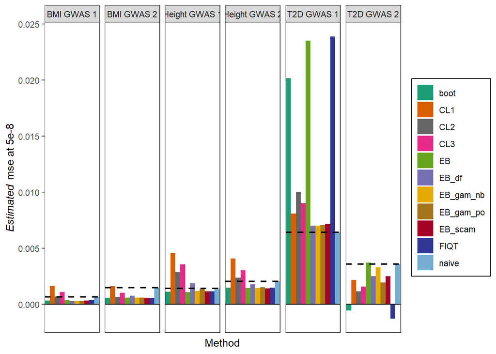

```
##       GWAS   naive     CL1     CL2     CL3      EB   EB_df EB_scam EB_gam_po
## 1    BMI 1 0.00244 0.00118 0.00078 0.00087 0.00074 0.00069 0.00071   0.00071
## 2    BMI 2 0.00289 0.00145 0.00102 0.00113 0.00085 0.00079 0.00077   0.00083
## 3    T2D 1 0.08837 0.01576 0.02869 0.02047 0.00478 0.00380 0.00327   0.00381
## 4    T2D 2 0.10361 0.02052 0.03669 0.02674 0.00851 0.00862 0.00833   0.00732
## 5 Height 1 0.00288 0.00296 0.00189 0.00229 0.00169 0.00206 0.00170   0.00177
## 6 Height 2 0.00315 0.00296 0.00189 0.00228 0.00173 0.00189 0.00168   0.00168
##   EB_gam_nb    boot    FIQT
## 1   0.00071 0.00077 0.00077
## 2   0.00081 0.00088 0.00087
## 3   0.00371 0.01264 0.00446
## 4   0.00626 0.01827 0.00781
## 5   0.00173 0.00168 0.00170
## 6   0.00172 0.00171 0.00172
```

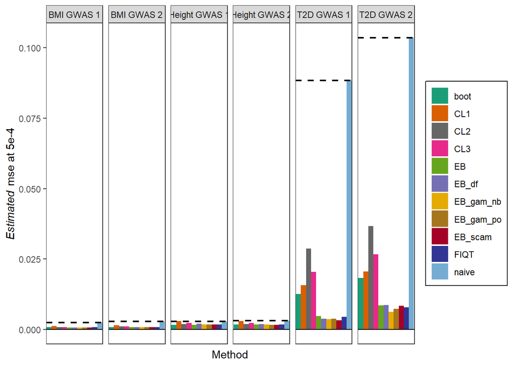